# College Majors Data Set

Kashyapee Mokal

06/12/2021

1:Introduction:- The data set that interested me the most is mainly about the analysis of earnings with respect to college majors. My Research question on this data set is-What influence do different factors, while choosing a major have, on a student’s career?The reason it interests me is, it provides a holistic view on different aspects for choosing a major and while answering some important questions,it helps making an informed decision for the future. Some of these questions are- 1:Which Major Category provides high salary jobs? 2:Which Major Category has highest Unemployment rate and which has highest employment rate? 3: Do women prefer high salaried jobs or low salaried jobs? 4:Is there a gender bias in choosing a major related to STEM(Engineering)? 5:Does employment require college degree jobs? All these are important to know to make a wise decision while choosing a career and making better life decisions.Each individual must be interested in which career option they must opt keeping in mind all of these factors.

2:Data:-The data set I am choosing for my final project is recent grads data set from a folder of college majors, available on FiveThirtyEight(https://fivethirtyeight.com/features/the-economic-guide-to-picking-a-college-major/). This folder includes many sub data sets, while the one that provided a proper insight and a detailed breakdown of many different factors was recent grads data set. All data is collected from American Community Survey 2010-2012 Public Use Microdata Series, which is an experimental study. Unit of Observation- Each unit of observation or row represents a Major.There 173 rows and 21 columns(variables). Variables I am interested in studying are-Major, Major Category, Total,Men and Women,Median,ShareWomen, Employed and College Jobs. Variables in the data set represent: Major=Major description,Major_category= Category of Major. Total= Total number of people with Major, Men=Male graduates, Women=Female graduates, Median=Median earnings of full-time, year-round workers. ShareWomen=Women as share of total,Employed=Number employed. College Jobs=Number of jobs that require a college degree. Summary of the dataset-

```r
library(tidyverse)
CM= (read.csv("recent-grads.csv"))
head(CM)
```

```
##   Rank Major_code                                     Major Total   Men Women
## 1    1       2419                     PETROLEUM ENGINEERING  2339  2057   282
## 2    2       2416            MINING AND MINERAL ENGINEERING   756   679    77
## 3    3       2415                 METALLURGICAL ENGINEERING   856   725   131
## 4    4       2417 NAVAL ARCHITECTURE AND MARINE ENGINEERING  1258  1123   135
## 5    5       2405                      CHEMICAL ENGINEERING 32260 21239 11021
## 6    6       2418                       NUCLEAR ENGINEERING  2573  2200   373
##   Major_category ShareWomen Sample_size Employed Full_time Part_time
## 1    Engineering  0.1205643          36     1976      1849       270
## 2    Engineering  0.1018519           7      640       556       170
## 3    Engineering  0.1530374           3      648       558       133
## 4    Engineering  0.1073132          16      758      1069       150
## 5    Engineering  0.3416305         289    25694     23170      5180
## 6    Engineering  0.1449670          17     1857      2038       264
##   Full_time_year_round Unemployed Unemployment_rate Median P25th  P75th
## 1                 1207         37        0.01838053 110000 95000 125000
## 2                  388         85        0.11724138  75000 55000  90000
## 3                  340         16        0.02409639  73000 50000 105000
## 4                  692         40        0.05012531  70000 43000  80000
## 5                16697       1672        0.06109771  65000 50000  75000
## 6                 1449        400        0.17722641  65000 50000 102000
##   College_jobs Non_college_jobs Low_wage_jobs
## 1         1534              364           193
## 2          350              257            50
## 3          456              176             0
## 4          529              102             0
## 5        18314             4440           972
## 6         1142              657           244
```

```r
summary(CM)
```

```
##       Rank       Major_code      Major               Total
##  Min.   :  1   Min.   :1100   Length:173         Min.   :   124
##  1st Qu.: 44   1st Qu.:2403   Class :character   1st Qu.:  4550
##  Median : 87   Median :3608   Mode  :character   Median : 15104
##  Mean   : 87   Mean   :3880                      Mean   : 39370
##  3rd Qu.:130   3rd Qu.:5503                      3rd Qu.: 38910
##  Max.   :173   Max.   :6403                      Max.   :393735
##                                                  NA's   :1
##       Men             Women        Major_category       ShareWomen
##  Min.   :   119   Min.   :     0   Length:173         Min.   :0.0000
##  1st Qu.:  2178   1st Qu.:  1778   Class :character   1st Qu.:0.3360
##  Median :  5434   Median :  8386   Mode  :character   Median :0.5340
##  Mean   : 16723   Mean   : 22647                      Mean   :0.5222
##  3rd Qu.: 14631   3rd Qu.: 22554                      3rd Qu.:0.7033
##  Max.   :173809   Max.   :307087                      Max.   :0.9690
##  NA's   :1        NA's   :1                           NA's   :1
##   Sample_size        Employed        Full_time        Part_time
##  Min.   :   2.0   Min.   :     0   Min.   :   111   Min.   :     0
##  1st Qu.:  39.0   1st Qu.:  3608   1st Qu.:  3154   1st Qu.:  1030
##  Median : 130.0   Median : 11797   Median : 10048   Median :  3299
##  Mean   : 356.1   Mean   : 31193   Mean   : 26029   Mean   :  8832
##  3rd Qu.: 338.0   3rd Qu.: 31433   3rd Qu.: 25147   3rd Qu.:  9948
##  Max.   :4212.0   Max.   :307933   Max.   :251540   Max.   :115172
##
##  Full_time_year_round   Unemployed    Unemployment_rate     Median
##  Min.   :   111       Min.   :    0   Min.   :0.00000   Min.   : 22000
##  1st Qu.:  2453       1st Qu.:  304   1st Qu.:0.05031   1st Qu.: 33000
##  Median :  7413       Median :  893   Median :0.06796   Median : 36000
##  Mean   : 19694       Mean   : 2416   Mean   :0.06819   Mean   : 40151
##  3rd Qu.: 16891       3rd Qu.: 2393   3rd Qu.:0.08756   3rd Qu.: 45000
##  Max.   :199897       Max.   :28169   Max.   :0.17723   Max.   :110000
##
##      P25th           P75th         College_jobs    Non_college_jobs
##  Min.   :18500   Min.   : 22000   Min.   :     0   Min.   :     0
##  1st Qu.:24000   1st Qu.: 42000   1st Qu.:  1675   1st Qu.:  1591
##  Median :27000   Median : 47000   Median :  4390   Median :  4595
##  Mean   :29501   Mean   : 51494   Mean   : 12323   Mean   : 13284
##  3rd Qu.:33000   3rd Qu.: 60000   3rd Qu.: 14444   3rd Qu.: 11783
##  Max.   :95000   Max.   :125000   Max.   :151643   Max.   :148395
##
##  Low_wage_jobs
##  Min.   :    0
##  1st Qu.:  340
##  Median : 1231
##  Mean   : 3859
##  3rd Qu.: 3466
##  Max.   :48207
##
```

Data Cleaning And Transformation: Here we don’t really need the major code variable for our analysis, so we can remove it and shorten the table. Also need to remove all the NA’s in the table.

```r
CM1 = select(CM,-Major_code)
CM2=na.omit(CM1)
```

Normalizing the data set for better analysis:

```r
numdata=CM2[,c(1,3,4,5,7,8,9,10,11,12,13,14,15,16,17,18,19,20,6,2)]
normalize_data=function(x){
  return((x-min(x))/(max(x)-min(x)))
  }
Major_category=numdata$Major_category
Major=numdata$Major
numdata_n=cbind(as.data.frame(lapply(numdata[,1:18], normalize_data)),Major_category,Major)
```

3:Exploratory Data Analysis:- Let’s perform exploratory data analysis for some of the questions which can provide a better insight for the data. 1:Which Major Category provides high salary jobs?

```r
CM5= numdata_n %>% group_by(Major_category) %>% summarise(Major_category,Median,Major) %>% arrange(desc(Median))
head(CM5)
```

```
## # A tibble: 6 x 3
## # Groups:   Major_category [1]
##   Major_category Median Major
##   <chr>           <dbl> <chr>
## 1 Engineering     1     PETROLEUM ENGINEERING
## 2 Engineering     0.602 MINING AND MINERAL ENGINEERING
## 3 Engineering     0.580 METALLURGICAL ENGINEERING
## 4 Engineering     0.545 NAVAL ARCHITECTURE AND MARINE ENGINEERING
## 5 Engineering     0.489 CHEMICAL ENGINEERING
## 6 Engineering     0.489 NUCLEAR ENGINEERING
```

We can observe from the table above that Major Petroleum Engineering falling in the major category of engineering has the highest median salary followed by Mining and Mineral Energy Engineering. Let’s visualize and check if Engineering has the highest paid salaries.

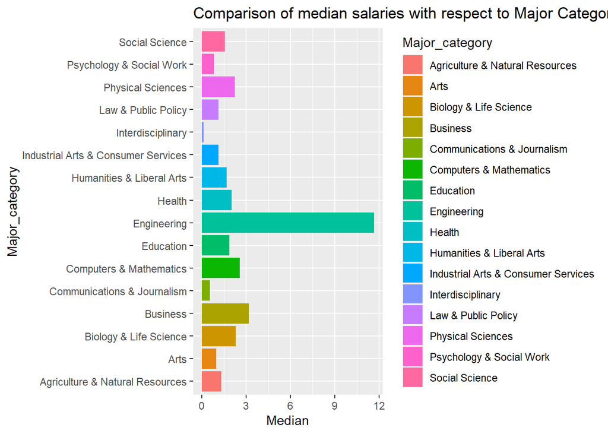

```r
ggplot(CM5,aes(x=Major_category, y=Median,fill=Major_category))+ geom_col()+coord_flip()+ggtitle('Comparison of median salaries with respect to Major Categories')
```

As we can see from the above bar plot Engineering has the highest paid jobs whereas interdisciplinary has lowest paid jobs.

2:Which Major Category has highest Unemployment rate and which has highest Employment rate?

```r
CM7= numdata_n %>% group_by(Major_category) %>% mutate(Employment_Rate=Employed/(sum(Employed+Unemployed))) %>% summarise(Employment_Rate,Unemployment_rate) %>% arrange(desc(Employment_Rate))
head(CM7)
```

```
## # A tibble: 6 x 3
## # Groups:   Major_category [6]
##   Major_category                      Employment_Rate Unemployment_rate
##   <chr>                                         <dbl>             <dbl>
## 1 Interdisciplinary                             0.545             0.400
## 2 Law & Public Policy                           0.429             0.465
## 3 Psychology & Social Work                      0.414             0.473
## 4 Biology & Life Science                        0.330             0.399
## 5 Industrial Arts & Consumer Services           0.327             0.290
## 6 Health                                        0.294             0.253
```

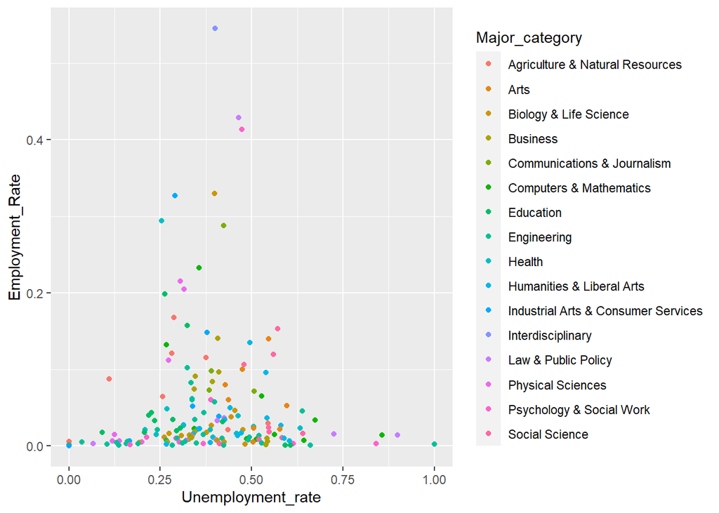

```r
ggplot(CM7,aes(y=Employment_Rate,x=Unemployment_rate,col=Major_category))+geom_point()
```

We can see from the above table and plot that Interdisciplinary major category has the highest employment rate whereas Engineering has highest unemployment rate.

3: Do women prefer high salaried jobs or low salaried jobs?

```r
zx=CM2 %>% group_by(Major_category) %>% summarise(Median,ShareWomen,Major)%>% arrange(desc(Median))
head(zx)
```

```
## # A tibble: 6 x 4
## # Groups:   Major_category [1]
##   Major_category Median ShareWomen Major
##   <chr>           <int>      <dbl> <chr>
## 1 Engineering    110000      0.121 PETROLEUM ENGINEERING
## 2 Engineering     75000      0.102 MINING AND MINERAL ENGINEERING
## 3 Engineering     73000      0.153 METALLURGICAL ENGINEERING
## 4 Engineering     70000      0.107 NAVAL ARCHITECTURE AND MARINE ENGINEERING
## 5 Engineering     65000      0.342 CHEMICAL ENGINEERING
## 6 Engineering     65000      0.145 NUCLEAR ENGINEERING
```

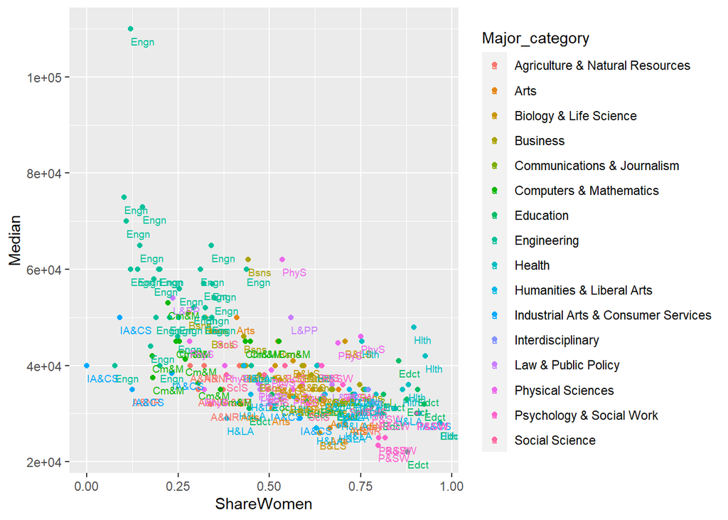

```r
ggplot(zx,aes(x=ShareWomen,y=Median, col=Major_category))+geom_point()+geom_text(mapping = aes(label=abbreviate(Major_category)),cex=2.5,hjust=0,vjust=2)
```

As we can see from the above point graph that most women have low salaried jobs. The outlier is for Engineering major category which is Petroleum Engineering major having the highest salary and lowest is for Education.We can also observe that most high paying jobs are from Engineering major category.

4:Is there a gender bias in choosing a major related to STEM(Engineering)? As Engineering is considered to be a male dominated field is it true based on the data that men are more in Engineering as compared to women?

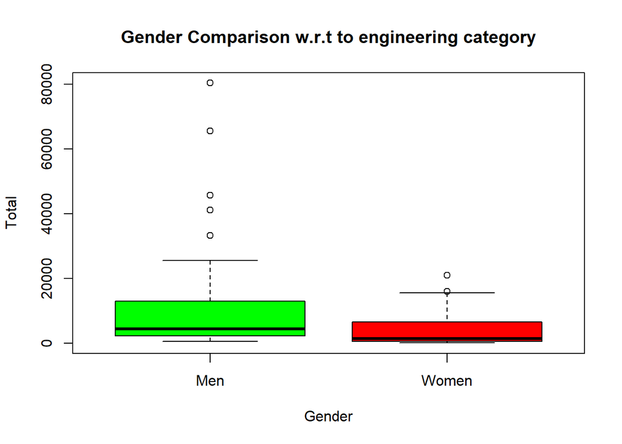

```r
CM6= CM2 %>% filter(Major_category=='Engineering') %>% group_by(Major) %>% summarise(Women, Men) %>% arrange(desc(Women,Men)) %>% gather(key = "Gender",value = "Enrolled",c(Women,Men))
boxplot(CM6$Enrolled~CM6$Gender,col=c("green","red"),xlab = "Gender",ylab = "Total",main="Gender Comparison w.r.t to engineering category")
```

It is evident from the boxplot that Engineering in this data seems to be dominated by men. Women are much less in comparison to that of Men.

4:Data Analysis: The two techniques i used for data analysis are Linear Regression and PCA.

Linear Regression: 5:Does employment require college degree jobs? As not all people get a job right after their degree is it worth taking a degree? Does it ensure jobs after college or would it be better to take non-college jobs avoiding the hassle of paying heavy tuition fees.

```r
mkn=select(numdata_n,c('Employed','College_jobs','Non_college_jobs','Low_wage_jobs'))
library(corrplot)
cor(mkn)
```

```
##                   Employed College_jobs Non_college_jobs Low_wage_jobs
## Employed         1.0000000    0.7971931        0.9412360     0.9271223
## College_jobs     0.7971931    1.0000000        0.6128772     0.6497199
## Non_college_jobs 0.9412360    0.6128772        1.0000000     0.9756995
## Low_wage_jobs    0.9271223    0.6497199        0.9756995     1.0000000
```

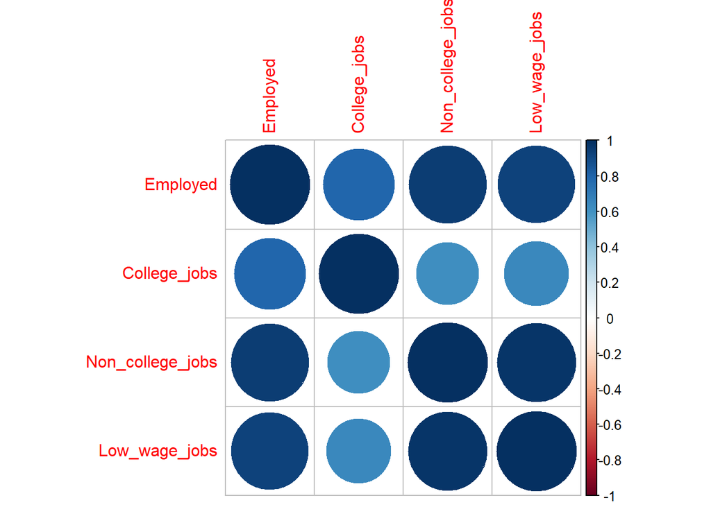

```r
corrplot(cor(mkn),method = "circle")
```

We can see the correlation value between Employed and college jobs is 0.797 or round it up to 80%, between Employed and Non-college jobs is 94%. Also the correlation between College jobs and low wages is 65% and Non-college jobs is 98% which is very close to 1 ,indicating strong relationship. So since Non college jobs and Employed variables show a strong relationship, we can fit a linear regression model for it.

Fitting a linear regression model where Employment rate is the dependent variable and Non College jobs is the predictor variable.

```r
yz=numdata_n %>% group_by(Major_category) %>% mutate(Employment_rate=Employed/sum(Employed+Unemployed)) %>% mutate(Non_college_jobs_rate=Non_college_jobs/sum(College_jobs+Non_college_jobs)) %>% summarise(Employment_rate,Non_college_jobs_rate,Major) %>% arrange(desc(Employment_rate))
```

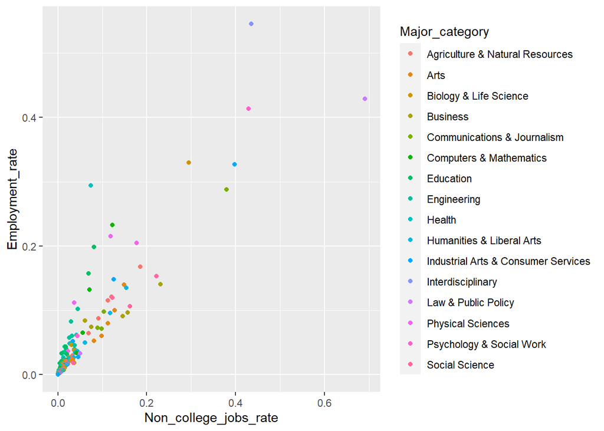

```r
ggplot(yz,aes(x=Non_college_jobs_rate,y=Employment_rate, col=Major_category))+geom_point()
```

From the above table and graph we can observe that highest number of employed people with non college jobs are from Interdisciplinary major category followed by law and public policy.

Dividing the data set into training and testing data set and fitting a linear model on the training data set:-

```r
library(caTools)
set.seed(2)
split_data=sample.split(yz,SplitRatio=0.7)
split_data
```

```
## [1]  TRUE FALSE FALSE  TRUE
```

```r
train_data= subset(yz,split_data="TRUE")
train_data
```

```
## # A tibble: 172 x 4
## # Groups:   Major_category [16]
##    Major_category         Employment_rate Non_college_jobs_~ Major
##    <chr>                            <dbl>              <dbl> <chr>
##  1 Interdisciplinary                0.545             0.435  MULTI/INTERDISCIPL~
##  2 Law & Public Policy              0.429             0.691  CRIMINAL JUSTICE A~
##  3 Psychology & Social W~           0.414             0.430  PSYCHOLOGY
##  4 Biology & Life Science           0.330             0.295  BIOLOGY
##  5 Industrial Arts & Con~           0.327             0.398  PHYSICAL FITNESS P~
##  6 Health                           0.294             0.0746 NURSING
##  7 Communications & Jour~           0.288             0.380  COMMUNICATIONS
##  8 Computers & Mathemati~           0.233             0.123  COMPUTER SCIENCE
##  9 Physical Sciences                0.215             0.118  CHEMISTRY
## 10 Physical Sciences                0.205             0.177  MULTI-DISCIPLINARY~
## # ... with 162 more rows
```

```r
test_data= subset(yz,split_data="FALSE")
test_data
```

```
## # A tibble: 172 x 4
## # Groups:   Major_category [16]
##    Major_category         Employment_rate Non_college_jobs_~ Major
##    <chr>                            <dbl>              <dbl> <chr>
##  1 Interdisciplinary                0.545             0.435  MULTI/INTERDISCIPL~
##  2 Law & Public Policy              0.429             0.691  CRIMINAL JUSTICE A~
##  3 Psychology & Social W~           0.414             0.430  PSYCHOLOGY
##  4 Biology & Life Science           0.330             0.295  BIOLOGY
##  5 Industrial Arts & Con~           0.327             0.398  PHYSICAL FITNESS P~
##  6 Health                           0.294             0.0746 NURSING
##  7 Communications & Jour~           0.288             0.380  COMMUNICATIONS
##  8 Computers & Mathemati~           0.233             0.123  COMPUTER SCIENCE
##  9 Physical Sciences                0.215             0.118  CHEMISTRY
## 10 Physical Sciences                0.205             0.177  MULTI-DISCIPLINARY~
## # ... with 162 more rows
```

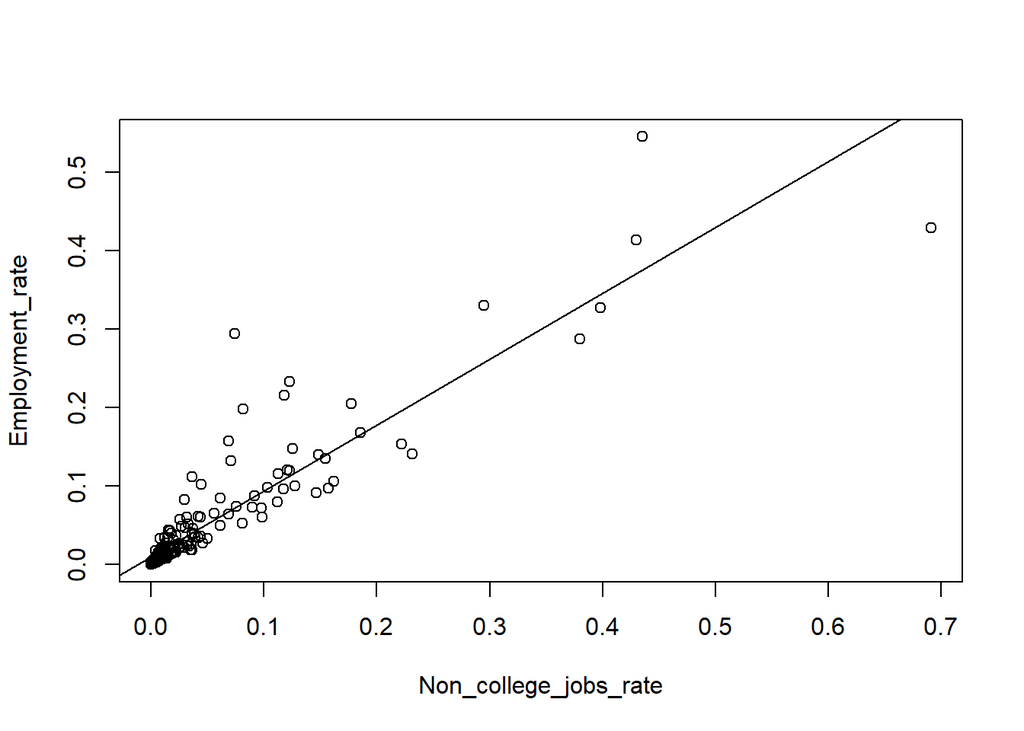

```r
regression=lm(Employment_rate~Non_college_jobs_rate,data=train_data)
plot(Employment_rate~Non_college_jobs_rate,yz)
abline(regression)
```

```r
summary(regression)
```

```
##
## Call:
## lm(formula = Employment_rate ~ Non_college_jobs_rate, data = train_data)
##
## Residuals:
##       Min        1Q    Median        3Q       Max
## -0.161171 -0.010573 -0.008017  0.001299  0.221380
##
## Coefficients:
##                       Estimate Std. Error t value Pr(>|t|)
## (Intercept)           0.010198   0.003034   3.361  0.00096 ***
## Non_college_jobs_rate 0.839448   0.029629  28.332  < 2e-16 ***
## ---
## Signif. codes:  0 '***' 0.001 '**' 0.01 '*' 0.05 '.' 0.1 ' ' 1
##
## Residual standard error: 0.03497 on 170 degrees of freedom
## Multiple R-squared:  0.8252, Adjusted R-squared:  0.8242
## F-statistic: 802.7 on 1 and 170 DF,  p-value: < 2.2e-16
```

```r
predict= predict(regression,test_data)
```

```r
cor(yz$Employment_rate,yz$Non_college_jobs_rate)
```

```
## [1] 0.9084237
```

```r
cor.test(yz$Employment_rate,yz$Non_college_jobs_rate)
```

```
##
##  Pearson's product-moment correlation
##
## data:  yz$Employment_rate and yz$Non_college_jobs_rate
## t = 28.332, df = 170, p-value < 2.2e-16
## alternative hypothesis: true correlation is not equal to 0
## 95 percent confidence interval:
##  0.8781586 0.9314454
## sample estimates:
##       cor
## 0.9084237
```

We can see that the correlation is positive and is 0.908 which is approximately equal to 91%. Meaning, as the Non college jobs rate increases we see an increase in the Employment rate. Correlation test rejects the null hypothesis which says correlation is equal to 0, which is rejected with a p value of 2.2e-16 which is much smaller than 0.05.

Predicting:- 1:Plotting original values:

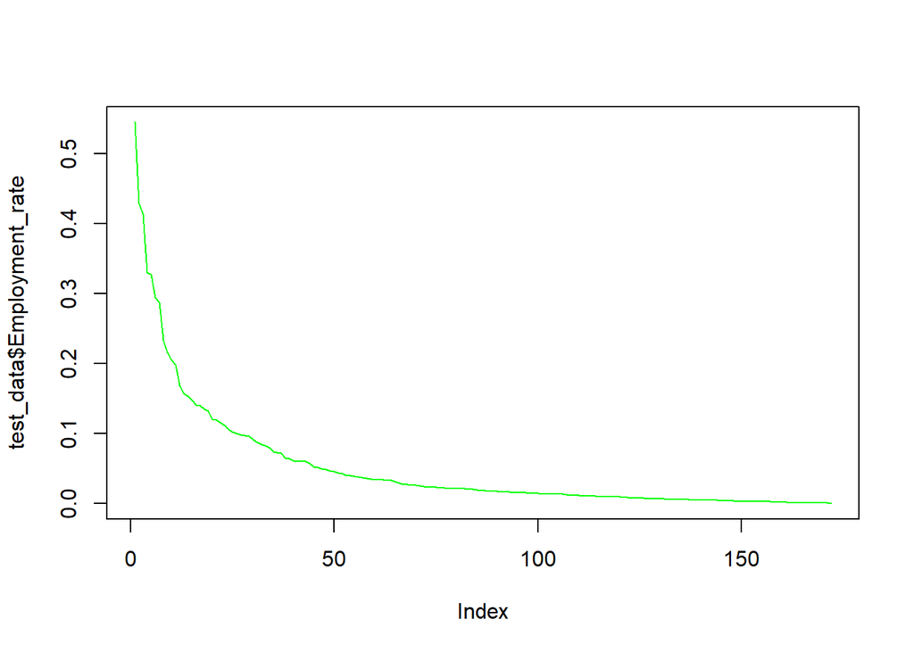

```r
plot(test_data$Employment_rate,type = "l",lty=1.8,col="green")
```

2:Plotting predicted values:

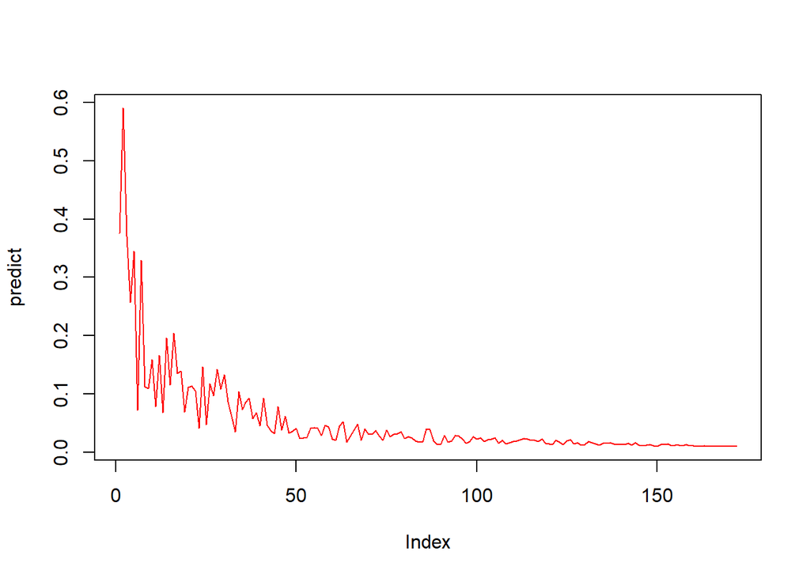

```r
plot(predict,type = "l",lty=1.8,col="red")
```

3:Plotting Predicted vs Actual Values:

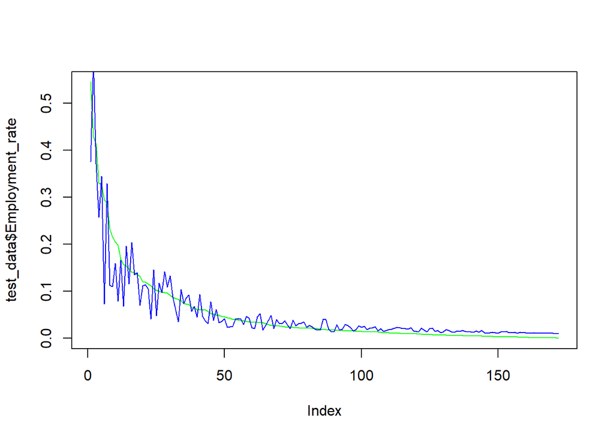

```r
plot(test_data$Employment_rate,type = "l",lty=1.8,col="green")
lines(predict,type="l",lty=1.8,col="blue")
```

We can see that our model has made a good a prediction, most of the blue line fits well on the green line indicating that predicted values are mostly correct.

Performing Adequacy Checks for Assumptions: 1: Linearity. 2: Normal Distribution.

```r
library(olsrr)
```

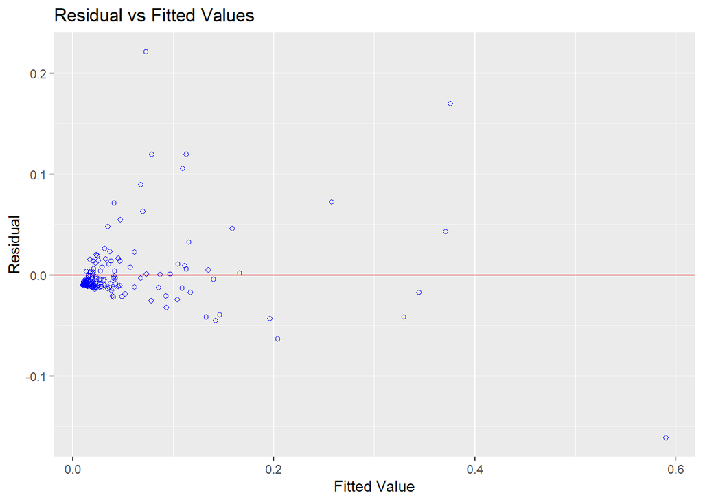

```r
ols_plot_resid_fit(regression)
```

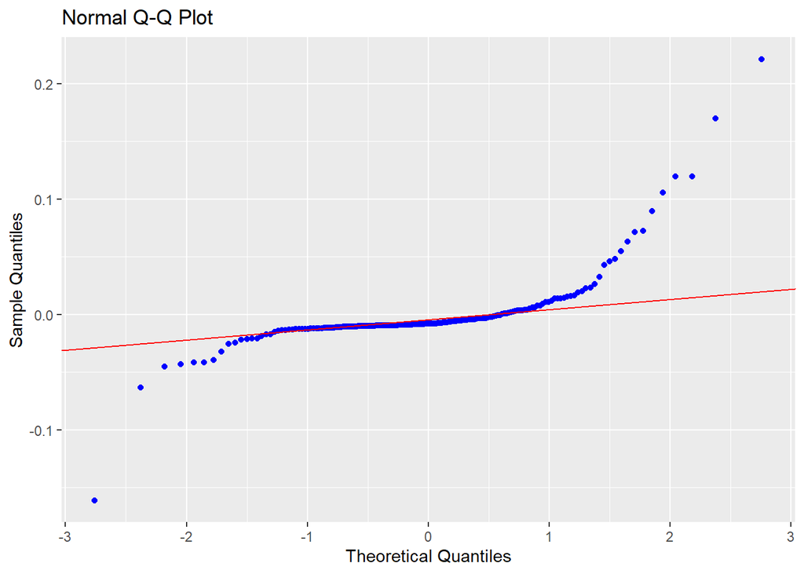

```r
ols_plot_resid_qq(regression)
```

The above residual plot show that linearity assumption has been met. But normality assumption is violated. We need to perform some transformation so the normality assumption is also met.

Performing Sqaure root ransformation method on the regression model:

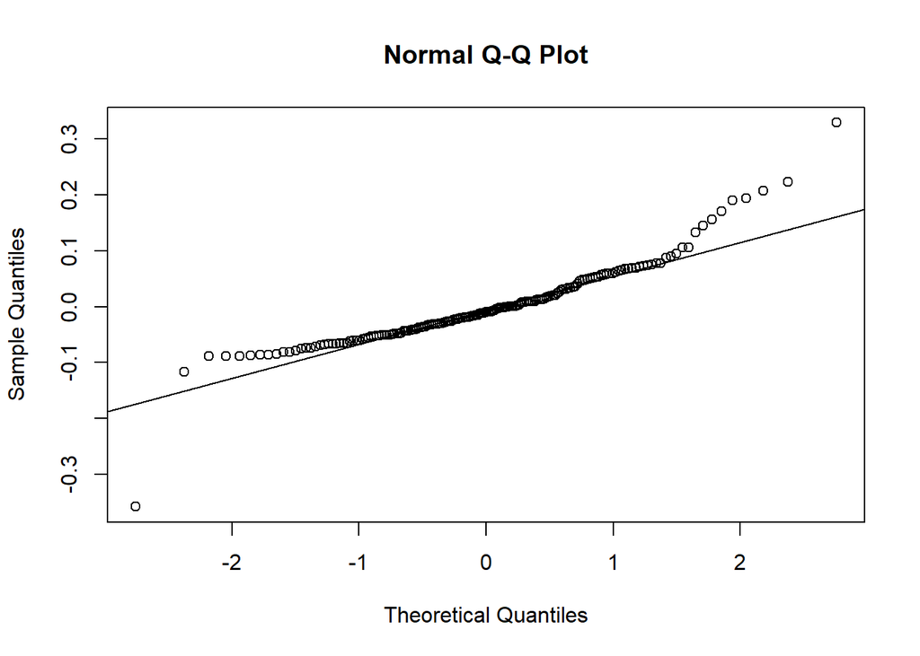

```r
regression1=lm(sqrt(Employment_rate)~Non_college_jobs_rate,data=yz)
residual=resid(regression1)
qqnorm(residual)
qqline(residual)
```

After the square root transformation we can see that normality assumption has also been met to most extent.

Principal Component Analysis: We can observe that there are 17 numerical variables in the data set. We can perform dimensionality reduction using PCA technique to reduce the number of dimensions. To particularly check if Major Category Engineering and Arts form separate clusters,meaning different factors affect both the major categories.

```r
numbers=select(CM2,-Major,-Major_category)
vara=var(numbers)
pca=prcomp(numbers[2:18],scale. = TRUE)
summary(pca)
```

```
## Importance of components:
##                           PC1    PC2     PC3     PC4     PC5     PC6     PC7
## Standard deviation     3.2979 1.7770 1.01391 0.86028 0.63466 0.55092 0.49449
## Proportion of Variance 0.6398 0.1858 0.06047 0.04353 0.02369 0.01785 0.01438
## Cumulative Proportion  0.6398 0.8255 0.88600 0.92954 0.95323 0.97108 0.98547
##                            PC8     PC9    PC10    PC11    PC12    PC13    PC14
## Standard deviation     0.35592 0.20839 0.19466 0.13398 0.09923 0.09050 0.04897
## Proportion of Variance 0.00745 0.00255 0.00223 0.00106 0.00058 0.00048 0.00014
## Cumulative Proportion  0.99292 0.99547 0.99770 0.99876 0.99934 0.99982 0.99996
##                           PC15    PC16      PC17
## Standard deviation     0.02381 0.01082 2.739e-16
## Proportion of Variance 0.00003 0.00001 0.000e+00
## Cumulative Proportion  0.99999 1.00000 1.000e+00
```

Principal components are the eigen vectors. So, the eigen vector that constitutes the most variance is the 1st eigen value which is the 1st principal component. So, the most variance is for PC1 followed by PC2 and till PC17 we can see the variance is 0. Here, in proportion of variance we can see that PC1 accounts for 64% variance, PC2 is 18%, PC3 6% and PC4 4% and so on till PC17 has 0% variance. We can see in cumulative proportion all variances up to PC4 constitute for 93% of the variance. So, we can consider 1st 4 principal components for our analysis, since they constitute much of variance. The dimensions can be reduced from 17 to 4.

Plotting PC1 and PC2:-

```r
numdata_n1=cbind(numbers,pca$x[,1:2])
cor(numbers,numdata_n1[19:20])
```

```
##                             PC1          PC2
## Rank                  0.1266567  0.861134761
## Total                 0.9958091 -0.060511293
## Men                   0.8625027 -0.230210178
## Women                 0.9489600  0.064120152
## ShareWomen            0.1857639  0.727823993
## Sample_size           0.9498941 -0.108946386
## Employed              0.9952631 -0.062714967
## Full_time             0.9863037 -0.093404705
## Part_time             0.9538947  0.047201903
## Full_time_year_round  0.9787447 -0.103566194
## Unemployed            0.9792557 -0.043634613
## Unemployment_rate     0.1048092  0.113248927
## Median               -0.1650329 -0.955830640
## P25th                -0.1240357 -0.883210513
## P75th                -0.1384958 -0.903168816
## College_jobs          0.7870946 -0.051741808
## Non_college_jobs      0.9570484  0.003459977
## Low_wage_jobs         0.9512409  0.055747993
```

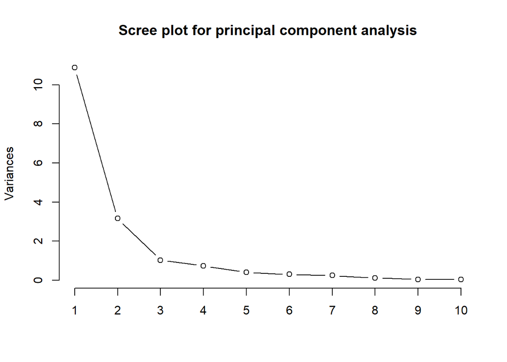

```r
plot(pca,type='l',main="Scree plot for principal component analysis")
```

As we can see from the Scree plot, that PC1 constitutes for the main variance. However, after PC2 the variance decreases considerably. Summarizing the correlation table, we can see that all the 17 variables increase with increase in PC1 value, except for Median, P25th and P75th salary. While for PC2 we can see that variables Rank, Women, Share Women, Part_time, Unemployment rate, non_college jobs and low_wage_jobs increase with increase in PC2 while all other variables decrease with increase in PC2.

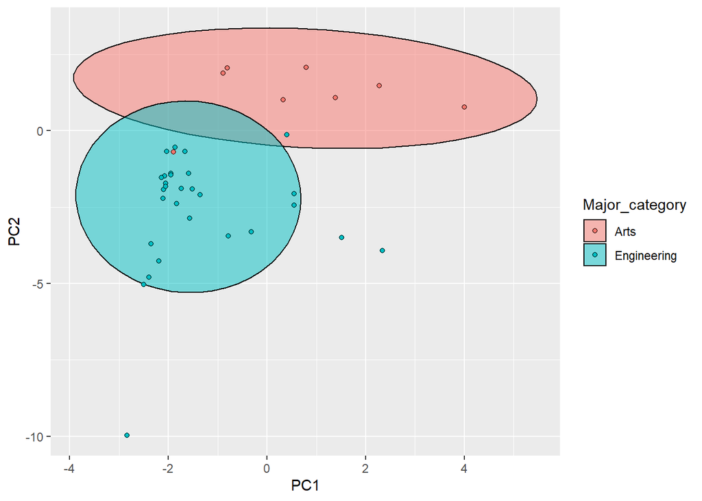

```r
numdata_n2= cbind(CM2,numdata_n1[19:20])  %>% filter( Major_category=='Engineering'| Major_category=='Arts') %>% group_by(Major_category)
ggplot(numdata_n2,aes(PC1,PC2,col=Major_category,fill=Major_category))+stat_ellipse(geom='polygon',col="black",alpha=0.5)+geom_point(shape=21,col="black")
```

5: Conclusion: Summarizing the analysis, in the data set and answering my research questions, we can see from the above first two questions that even though Engineering has high paid jobs it has highest unemployment rate while interdisciplinary being the lowest paid has highest employment rate. This analysis can leads us to the conclusion that due to high salaries most people are drawn towards Engineering but not many seek Employment after it.On the other hand Interdisciplinary has highest employment because there isn’t much competition and most people land up a job even it is low salaried. College degrees that ensure employment are less as compared to jobs that don’t require a college degree but have low salaried jobs as compared to the College Jobs. We can observe that most women tend to prefer jobs with low salaries except for Engineering which offers a good pay. Even though Engineering has good salary we can see it is dominated by men, and we can notice the gender bias for it.Men in Engineering are higher as compared to the women. As the number of men are much higher in Engineering we can say that men are more inclined towards high salaried job as Engineering has the highest pay. Linear regression predicts the Employment rate with respect to the non college jobs rate. Here we can analyse that even the employment is more for jobs which don’t require a college degree as compared to the ones who require a college degree. But it non college jobs have more low wages jobs as compared to College jobs. From PCA we can say that different factors affect Engineering and Arts major category leading to the formation of clusters and we observed that 17 variables can be decomposed within 4 main principal components to account for most variability. In conclusion we can say that many factors can influence Major categories, while the major factors are the employment, the salary,college and non college jobs and the gender.This data set provides a good insight for choosing the right direction for one’s future though it doesn’t involve the fees for each major which could provide better return on investment analysis.If this factor could be added in future, it would provide a holistic information for better analysis.

6: References: https://fivethirtyeight.com/features/the-economic-guide-to-picking-a-college-major/ https://www.rdocumentation.org/packages/VGAM/versions/1.1-5/topics/yeo.johnson https://cran.r-project.org/web/packages/olsrr/vignettes/heteroskedasticity.html#:~:text=Introduction,problem%20is%20known%20as%20heteroscedasticity. https://people.revoledu.com/kardi/tutorial/Similarity/Normalization.html